# Title of Blog Post Deliverable

## 2.5 Question five

Question five wants to study the relationship between the difference in probabilities (with vs without home field advantage) and advantage factor. In this case, the analytic method is a good choice because it is completely based on theory and is fixed. Firstly, I will define a sequence of possible advantage factors. The range is very important otherwise the probability may larger than 1 or smaller than 0. Then for each possible advantage factor, I will use the same method as Question one to calculate the probability of the Braves winning the game with and without home field advantage . Finally, I will calculate the difference and plot it with the corresponding advantage factor.

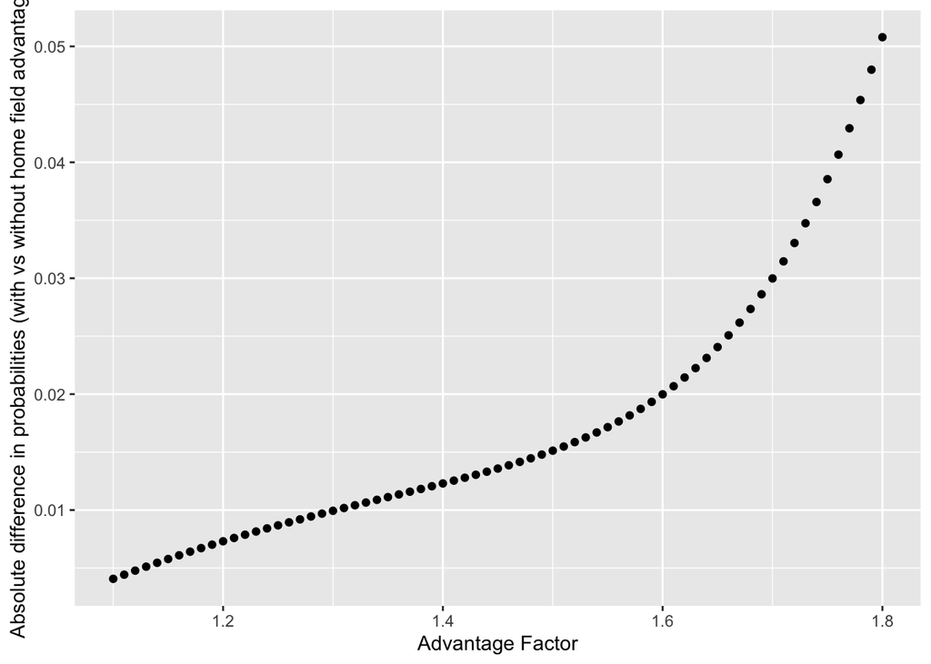

```r
# define the advantage factor list, the
advantage_list <- seq(1.1,1.8,0.01)
diff_ques_five <- rep(0,length(advantage_list))

#advantage_multiplier <- 1.1 # Set = 1 for no advantage
hfi <- c(0,0,1,1,1,0,0) # {NYC, NYC, ATL, ATL, ATL, NYC, NYC}
apo[, p_five := NA_real_]

for( i in 1:length(advantage_list))
{
  # different advantage factor
  pbh <- 0.55*advantage_list[i]
  pba <- 1 - (1 - 0.55)*advantage_list[i]

  for(j in 1:nrow(apo)){
    prob_game <- rep(1, 7)
    for(t in 1:7){
      p_win <- ifelse(hfi[t], pbh, pba)
      prob_game[t] <- case_when(
        apo[j,t,with=FALSE] == "W" ~ p_win
      , apo[j,t,with=FALSE] == "L" ~ 1-p_win
      , TRUE ~ 1
      )
    }
    apo[j,p_five := prod(prob_game)]
  }
  diff_ques_five[i] = abs(apo[,sum(p_five),overall_outcome][[2]][1] - pnbinom(3,4,0.55))
}
# draw the graphic
data.frame(advantage_list, diff_ques_five) %>%
  ggplot(aes(x=advantage_list, y = diff_ques_five)) +
  geom_point()+
  labs(
    x = "Advantage Factor",
    y = "Absolute difference in probabilities (with vs without home field advantage)"
  )
```

The X-axis is the advantage factor and the Y-axis is the absolute difference in probabilities with and without home field advantage. The difference keeps increasing with the increase of advantage factor